# Explore and Summarize Red Wine by Salma Refaat

Jan 2, 2018

> Data Structure

```
## [1] 1599   12
```

> There are 12 variables and 1599 observation

```
## 'data.frame':    1599 obs. of  12 variables:
##  $ fixed.acidity       : num  7.4 7.8 7.8 11.2 7.4 7.4 7.9 7.3 7.8 7.5 ...
##  $ volatile.acidity    : num  0.7 0.88 0.76 0.28 0.7 0.66 0.6 0.65 0.58 0.5 ...
##  $ citric.acid         : num  0 0 0.04 0.56 0 0 0.06 0 0.02 0.36 ...
##  $ residual.sugar      : num  1.9 2.6 2.3 1.9 1.9 1.8 1.6 1.2 2 6.1 ...
##  $ chlorides           : num  0.076 0.098 0.092 0.075 0.076 0.075 0.069 0.065 0.073 0.071 ...
##  $ free.sulfur.dioxide : num  11 25 15 17 11 13 15 15 9 17 ...
##  $ total.sulfur.dioxide: num  34 67 54 60 34 40 59 21 18 102 ...
##  $ density             : num  0.998 0.997 0.997 0.998 0.998 ...
##  $ pH                  : num  3.51 3.2 3.26 3.16 3.51 3.51 3.3 3.39 3.36 3.35 ...
##  $ sulphates           : num  0.56 0.68 0.65 0.58 0.56 0.56 0.46 0.47 0.57 0.8 ...
##  $ alcohol             : num  9.4 9.8 9.8 9.8 9.4 9.4 9.4 10 9.5 10.5 ...
##  $ quality             : int  5 5 5 6 5 5 5 7 7 5 ...
```

> All the variable are numarical except quality is score from 0 to 10.

> Variable Units: 1 - fixed acidity (tartaric acid - g / dm^3) 2 - volatile acidity (acetic acid - g / dm^3) 3 - citric acid (g / dm^3) 4 - residual sugar (g / dm^3) 5 - chlorides (sodium chloride - g / dm^3 6 - free sulfur dioxide (mg / dm^3) 7 - total sulfur dioxide (mg / dm^3) 8 - density (g / cm^3) 9 - pH 10 - sulphates (potassium sulphate - g / dm3) 11 - alcohol (% by volume) Output variable (based on sensory data): 12 - quality (score between 0 and 10)

# Univariate Plots Section

> Let’s explore fixed acidity

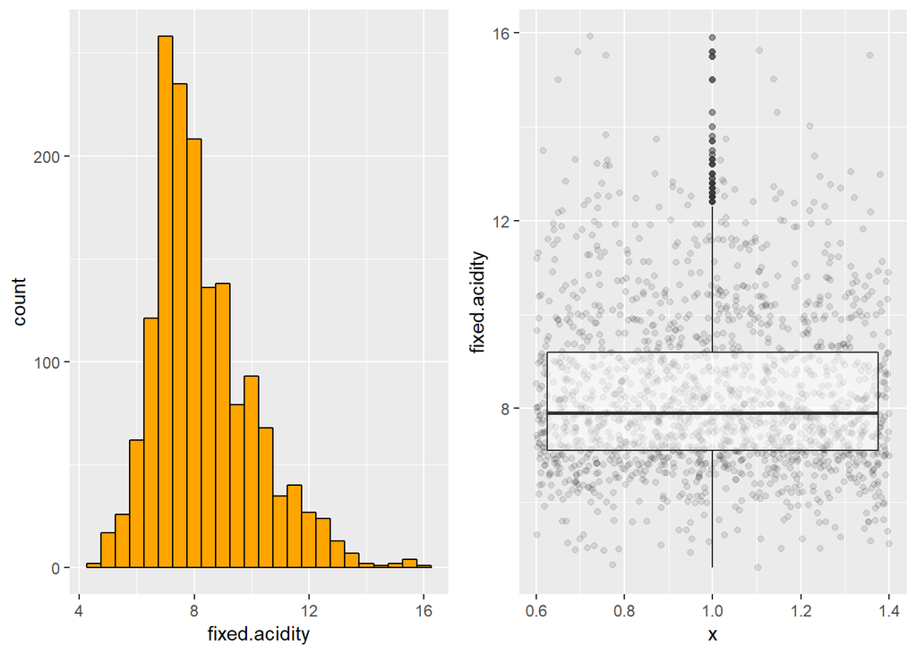

```
##    Min. 1st Qu.  Median    Mean 3rd Qu.    Max.
##    4.60    7.10    7.90    8.32    9.20   15.90
```

> Most frequent point

```
## 7.2
##  67
```

> Fixed acidity has positive skewed distribution due to high value outliers and the distribution peaks at 7.2.Data range from 4.6 to 15.9 with median equal to 7.9, 75% of data have value less than 9.2 and 25% of data have value less than 7.1.

> Let’s explore volatile acidity

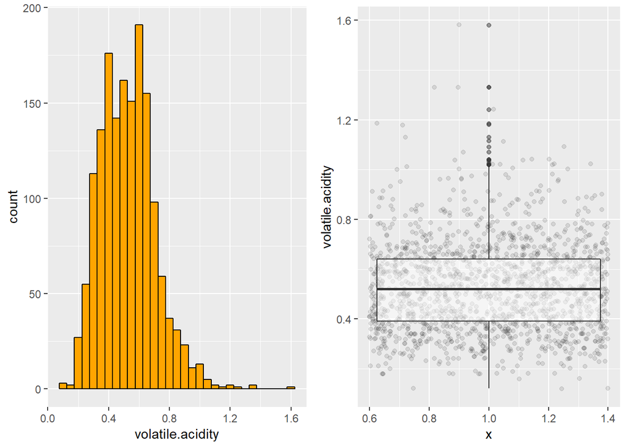

```
##    Min. 1st Qu.  Median    Mean 3rd Qu.    Max.
##  0.1200  0.3900  0.5200  0.5278  0.6400  1.5800
```

> Most frequent point

```
## 0.6
##  47
```

> Volatile acidity has positive skewed distribution due to high value outliers and the distribution peaks at 0.6.Data range from 0.12 to 1.58 with median equal to 0.52, 75% of data have value less than 0.64 and 25% of data have value less than 0.39.

> Let’s explore citric acid

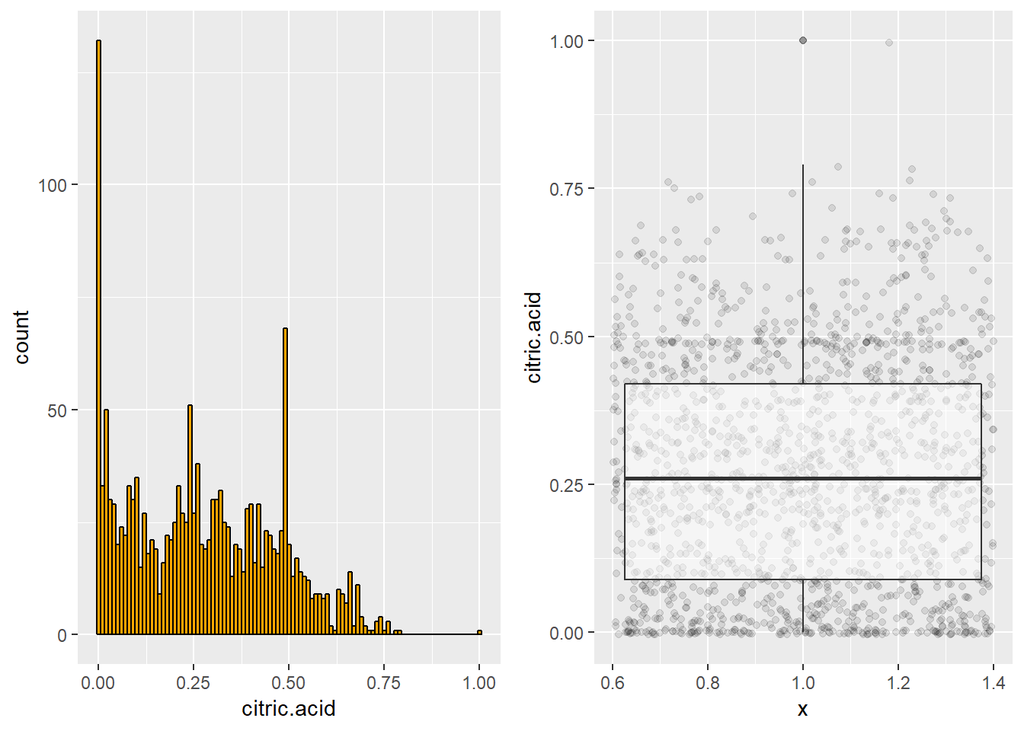

```
##    Min. 1st Qu.  Median    Mean 3rd Qu.    Max.
##   0.000   0.090   0.260   0.271   0.420   1.000
```

> Most frequent point

```
##   0
## 132
```

> Let’s explore residual sugar

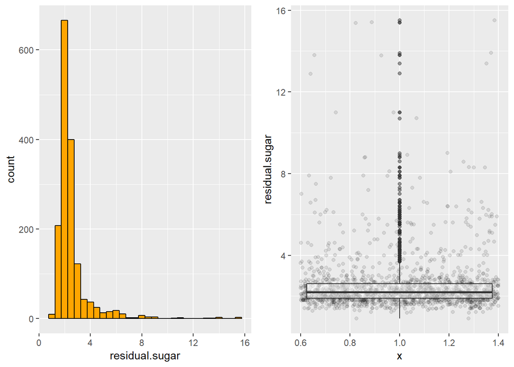

```
##    Min. 1st Qu.  Median    Mean 3rd Qu.    Max.
##   0.900   1.900   2.200   2.539   2.600  15.500
```

> Most frequent point

```
##   2
## 156
```

> Residual sugar has positive skewed distribution due to many high value outliers and the distribution peaks at 2.Data range from 0.9 to 15.5 with median equal to 2.2, 75% of data have value less than 2.6 and 25% of data have value less than 1.9.I’m interested with the effecct of these extreme high value with quality.

> Let’s explore chlorides

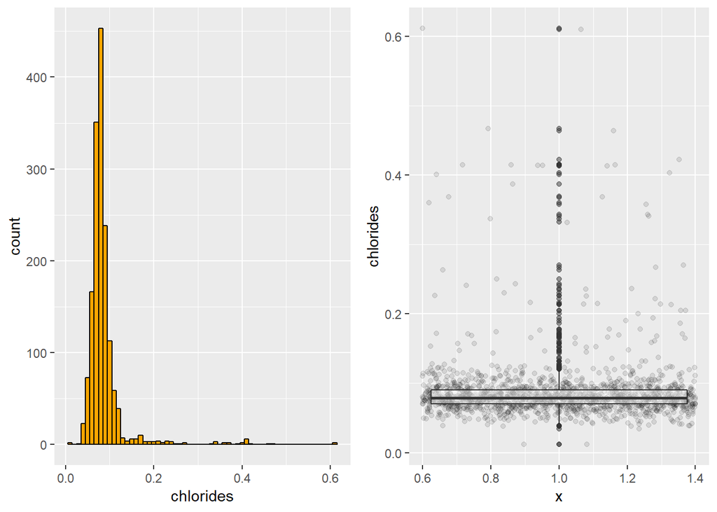

```
##    Min. 1st Qu.  Median    Mean 3rd Qu.    Max.
## 0.01200 0.07000 0.07900 0.08747 0.09000 0.61100
```

> Most frequent point

```
## 0.08
##   66
```

> Chlorides has positive skewed distribution due to many high value outliers and the distribution peaks at 0.08.Data range from 0.012 to 0.611 with median equal to 0.079, 75% of data have value less than 0.09 and 25% of data have value less than 0.07.

> Let’s explore free.sulfur.dioxide

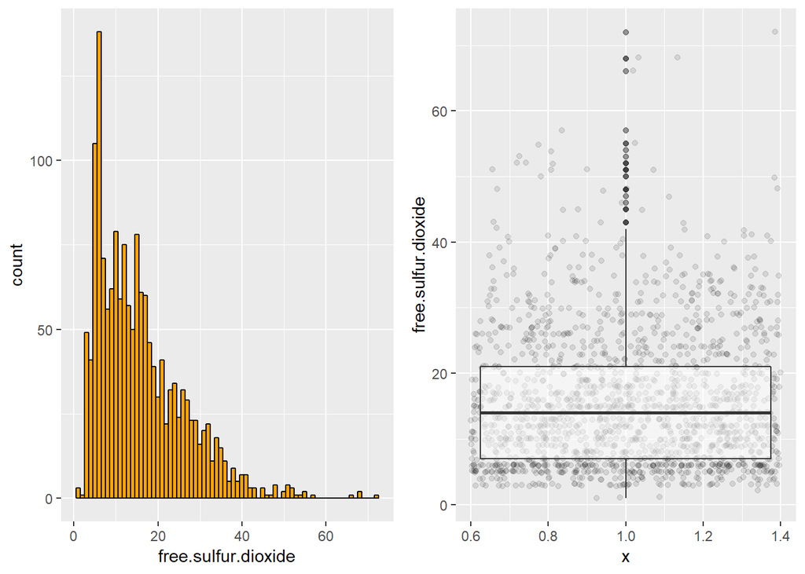

```
##    Min. 1st Qu.  Median    Mean 3rd Qu.    Max.
##    1.00    7.00   14.00   15.87   21.00   72.00
```

> Most frequent point

```
##   6
## 138
```

> Free sulfur dioxode has positive skewed distribution due to many high value outliers and the distribution peaks at 6,.Data range from 1 to 72 with median equal to 14, 75% of data have value less than 21 and 25% of data have value less than 7.

> Let’s explore total sulfur dioxide

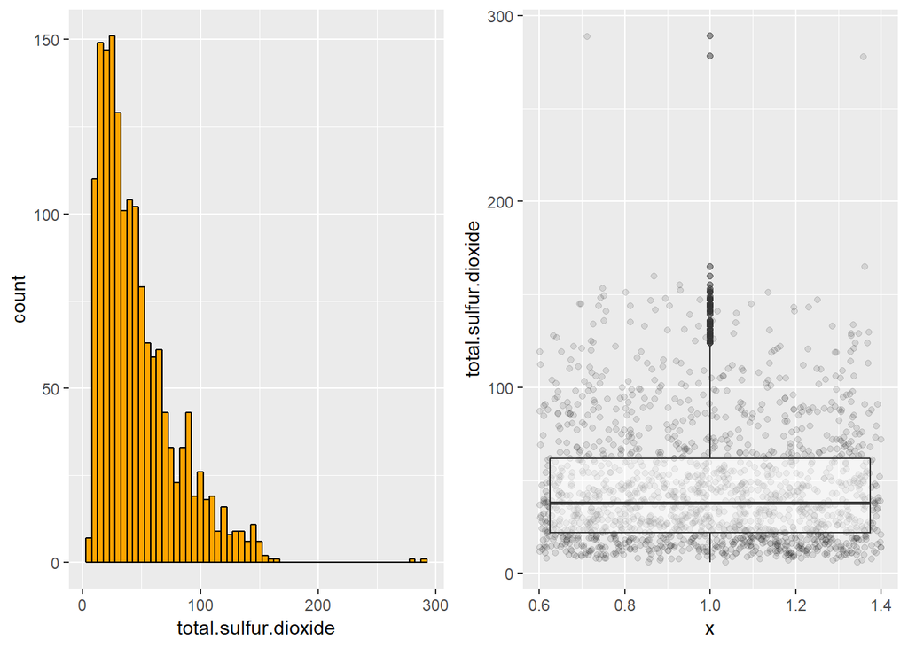

```
##    Min. 1st Qu.  Median    Mean 3rd Qu.    Max.
##    6.00   22.00   38.00   46.47   62.00  289.00
```

> Most frequent point

```
## 28
## 43
```

> Total sulfur dioxode has positive skewed distribution due to many high value outliers and the distribution peaks at 28.Data range from 6 to 289 with median equal to 38, 75% of data have value less than 62 and 25% of data have value less than 22.

> Let’s explore density

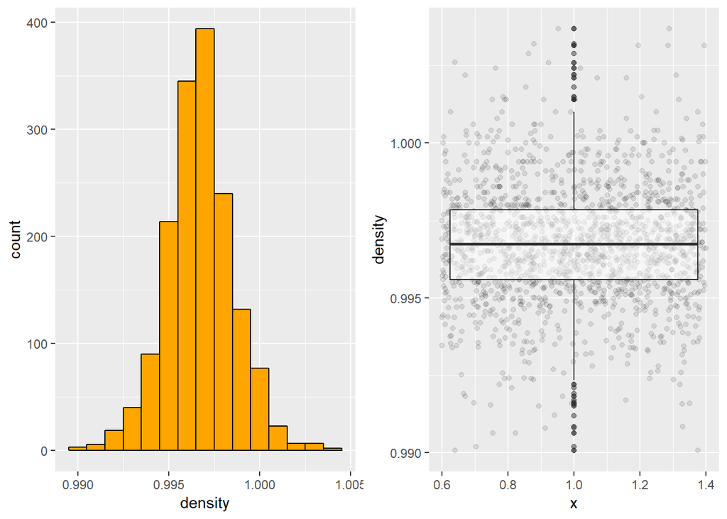

```
##    Min. 1st Qu.  Median    Mean 3rd Qu.    Max.
##  0.9901  0.9956  0.9968  0.9967  0.9978  1.0037
```

> Most frequent point

```
## 0.9972
##     36
```

> Density has normal distribution which peaks at 0.9972, data range from 0.9901 to 1.0037

> Let’s explore pH

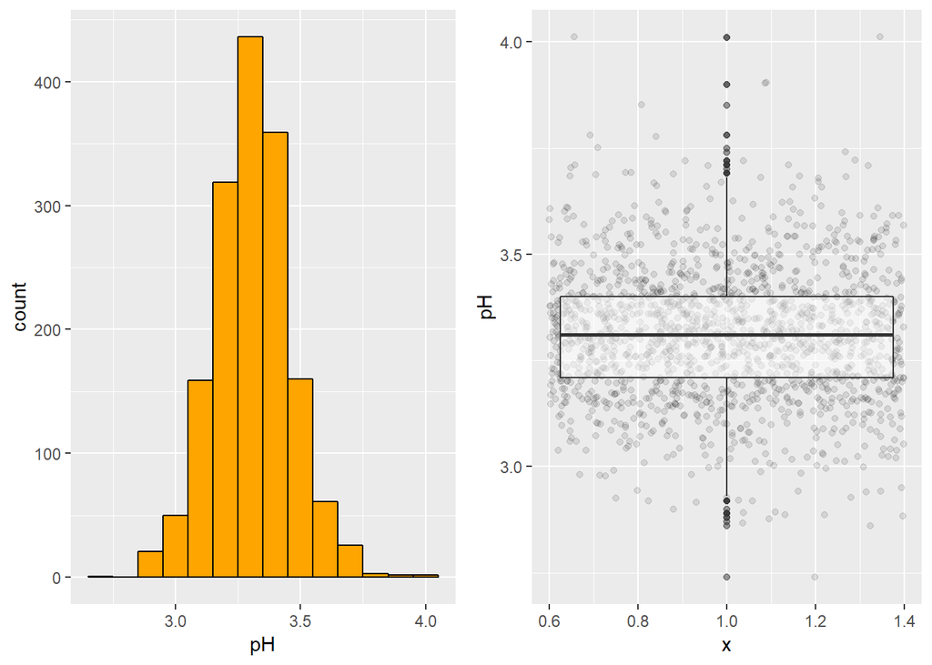

```
##    Min. 1st Qu.  Median    Mean 3rd Qu.    Max.
##   2.740   3.210   3.310   3.311   3.400   4.010
```

> Most frequent point

```
## 3.3
##  57
```

> pH has normal distribution peaks at 3.3, data range from 2.74 to 4.01

> Let’s explore sulphates

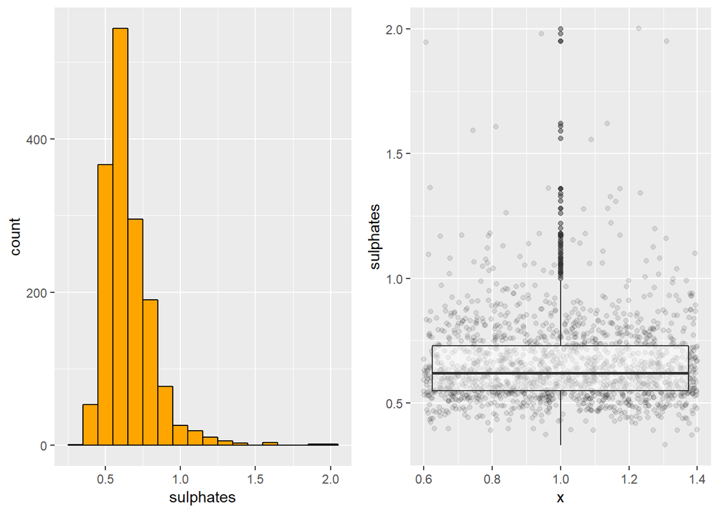

```
##    Min. 1st Qu.  Median    Mean 3rd Qu.    Max.
##  0.3300  0.5500  0.6200  0.6581  0.7300  2.0000
```

> Most frequent point

```
## 0.6
##  69
```

> Sulphates has positive skewed distribution due to many high value outliers and the distribution peaks at0.6.Data range from 0.33 to 2 with median equal to 0.62, 75% of data have value less than 0.73 and 25% of data have value less than 0.55.

> Let’s explore alcohol

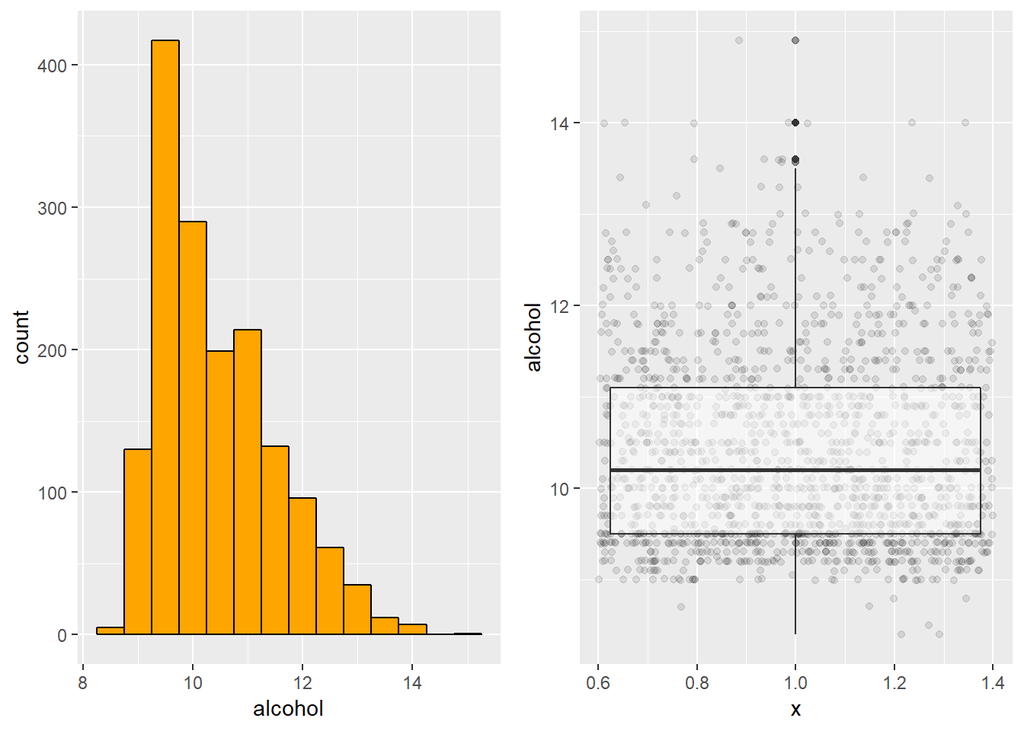

```
##    Min. 1st Qu.  Median    Mean 3rd Qu.    Max.
##    8.40    9.50   10.20   10.42   11.10   14.90
```

> Most frequent point

```
## 9.5
## 139
```

> alcohol has positive skewed distribution due to many high value outliers and the distribution peaks at 9.5 .Data range from 8.4 to 14.9 with median equal to 10.2, 75% of data have value less than 11.1 and 25% of data have value less than 9.5.

> Finally let’s explore quality

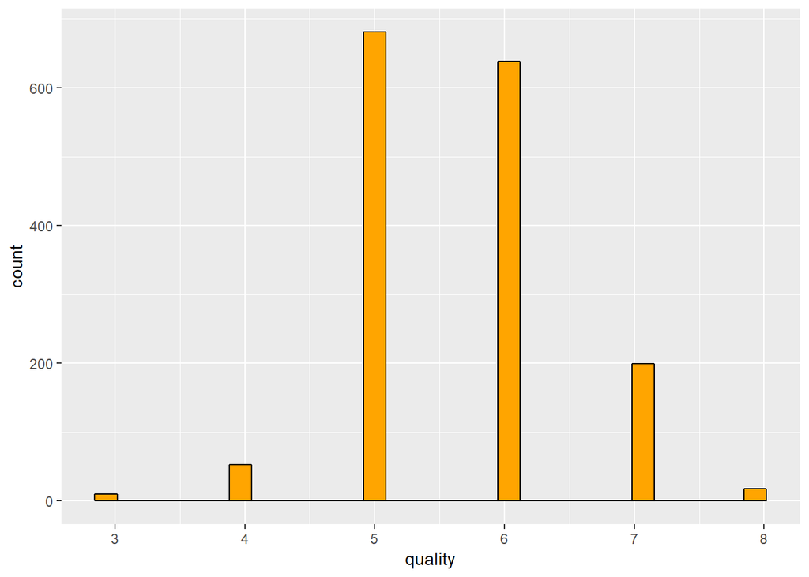

```
##    Min. 1st Qu.  Median    Mean 3rd Qu.    Max.
##   3.000   5.000   6.000   5.636   6.000   8.000
```

> Quality has normal distributed ,most of the data have value of 5 ,data range from 3 to 8

# Univariate Analysis

Our data contain of 12 variables with 1599 observation, all the variables are numarical except quality whichis score from 0 to 10 The main feature of interesr is quality and how does it affect by other factors. Next I will investigate all the variables in my guess the all have some rule in determining the wine quality. From pur earlier investegation I found that Quality,pH and density have normal distribution all other variable have positive skewed distribution due to high value outliers

# Bivariate Plots Section

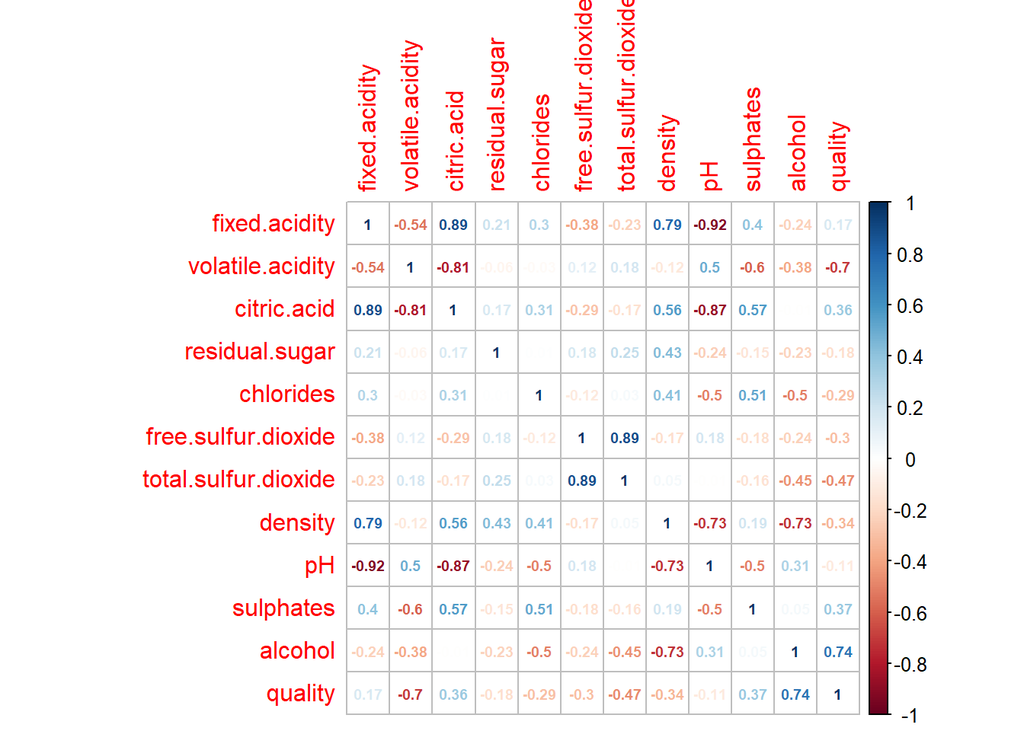

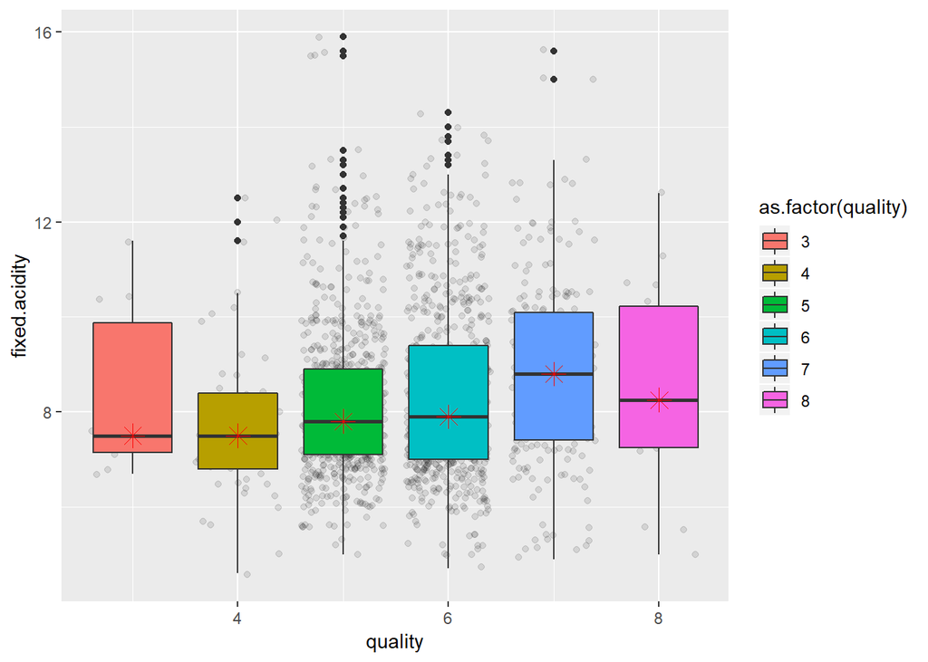

```r
biv_plot("quality","fixed.acidity")
```

>There is no clear relation between quality and fixed acidity, although the median of fixed acidity increase at quality of 7 it decrease again at quality of 8.

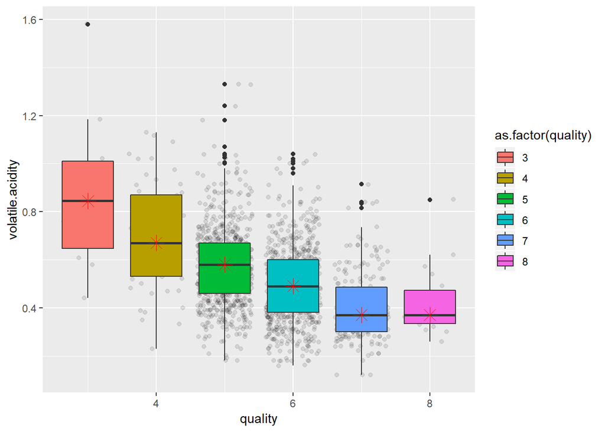

Here I can see a clear negative relationship between quality and volatile acidity

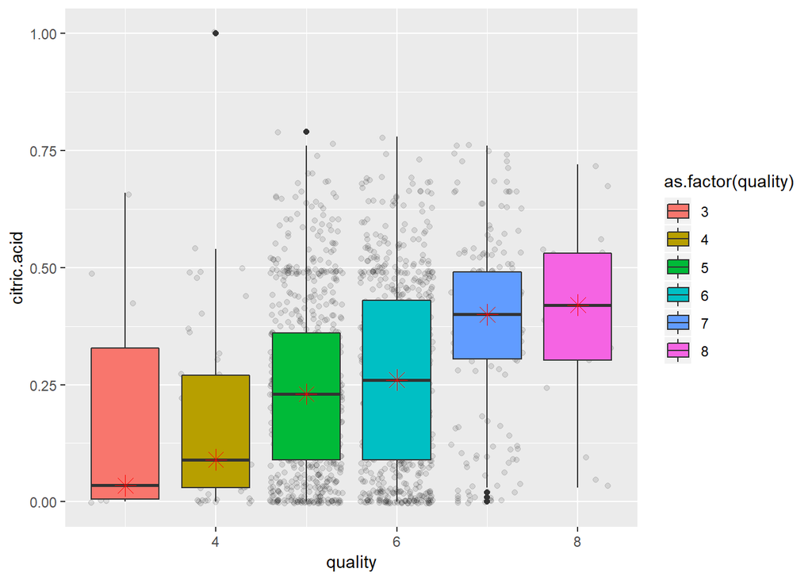

> Quality seems to increase when citric acid increase

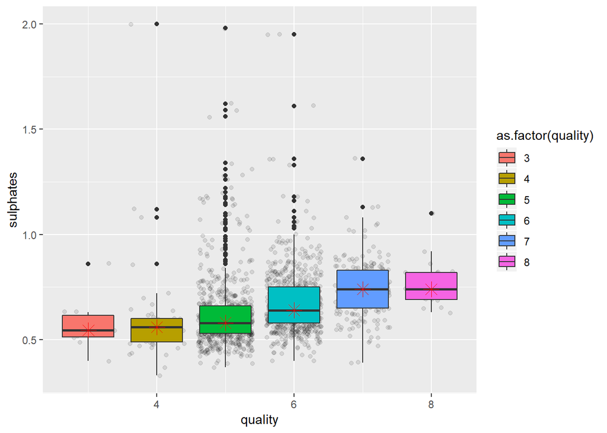

> Quality seems to increase when sulphates increase

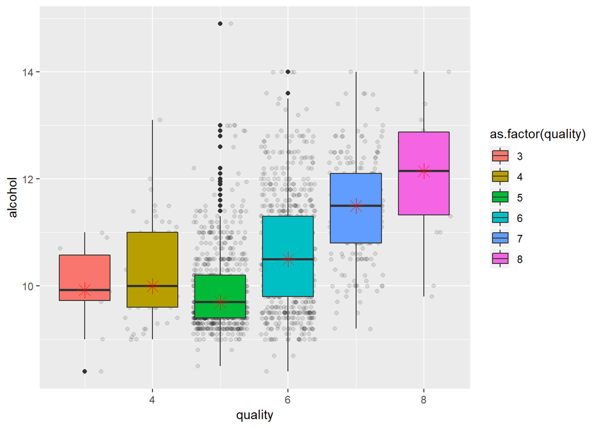

> Although there are drop in alcohol content at quality if 5, it’s seem that quality increase when alcohol increase

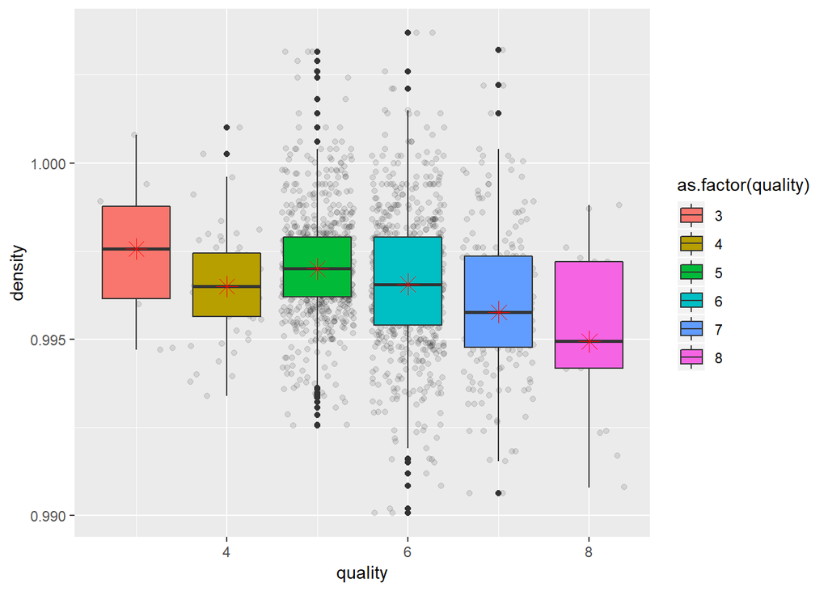

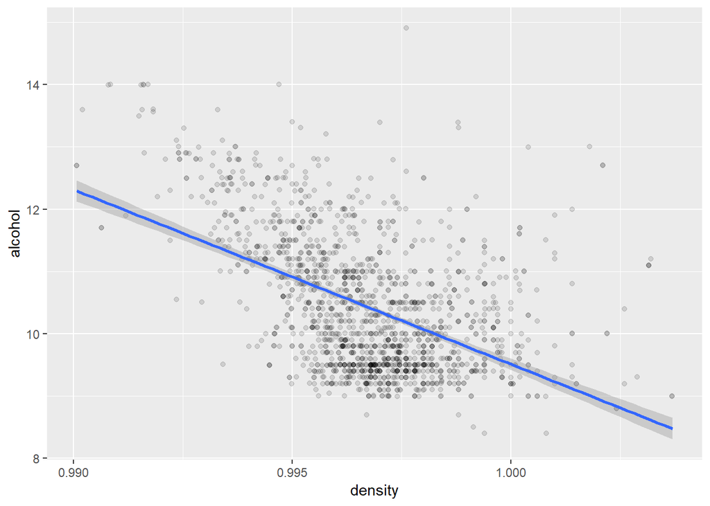

there are clear relationship between alcohol and density when density increase alcohol decrease which means lower quality

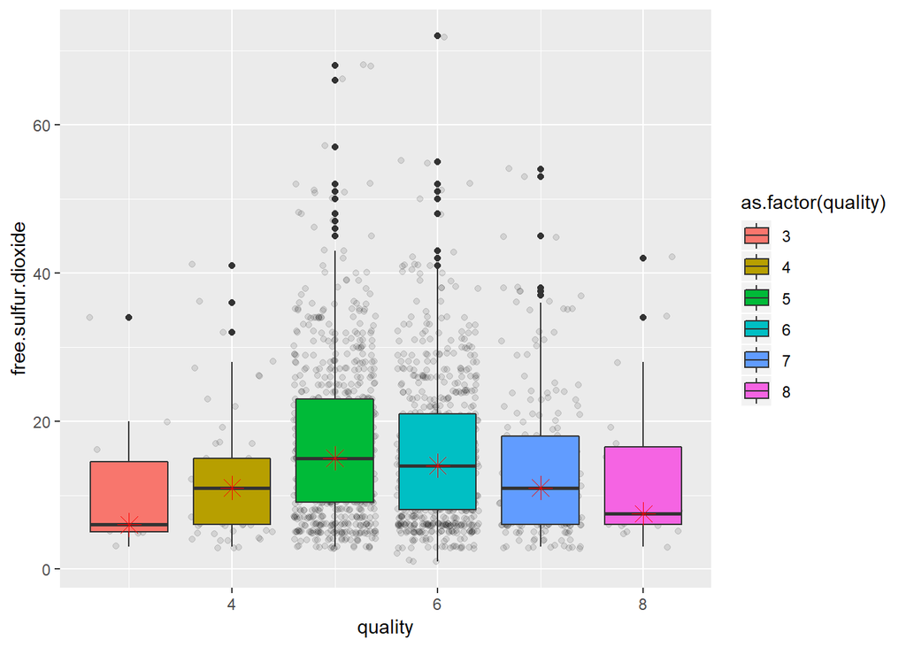

> Here i can see that higher free sulfue dioxide means medium quality

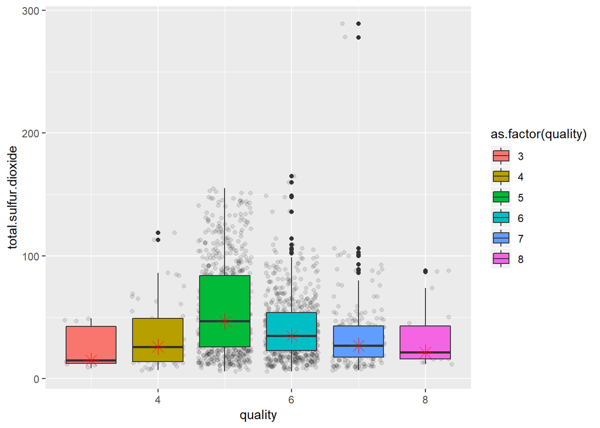

> The same pattern as above and this make sense as this is a Subset of Free Sulphur Dioxide

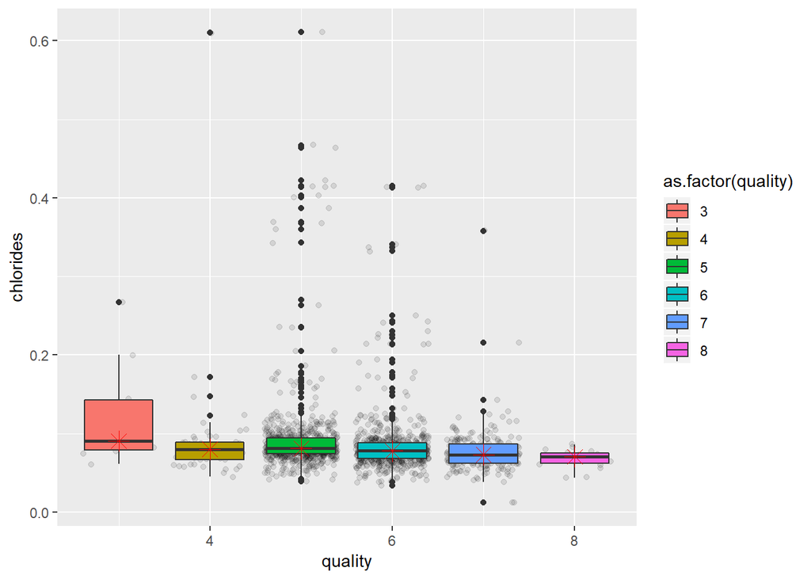

>There are very weak relationship between these two variables, but seems like lower chlorides means better wine

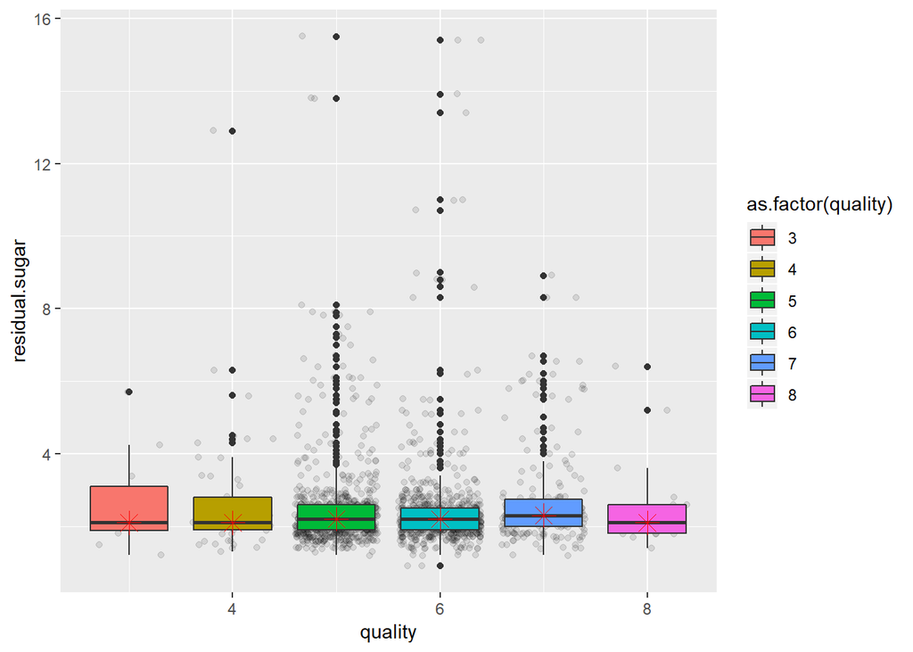

> Residual sugar almost has no effect in the quality of wine

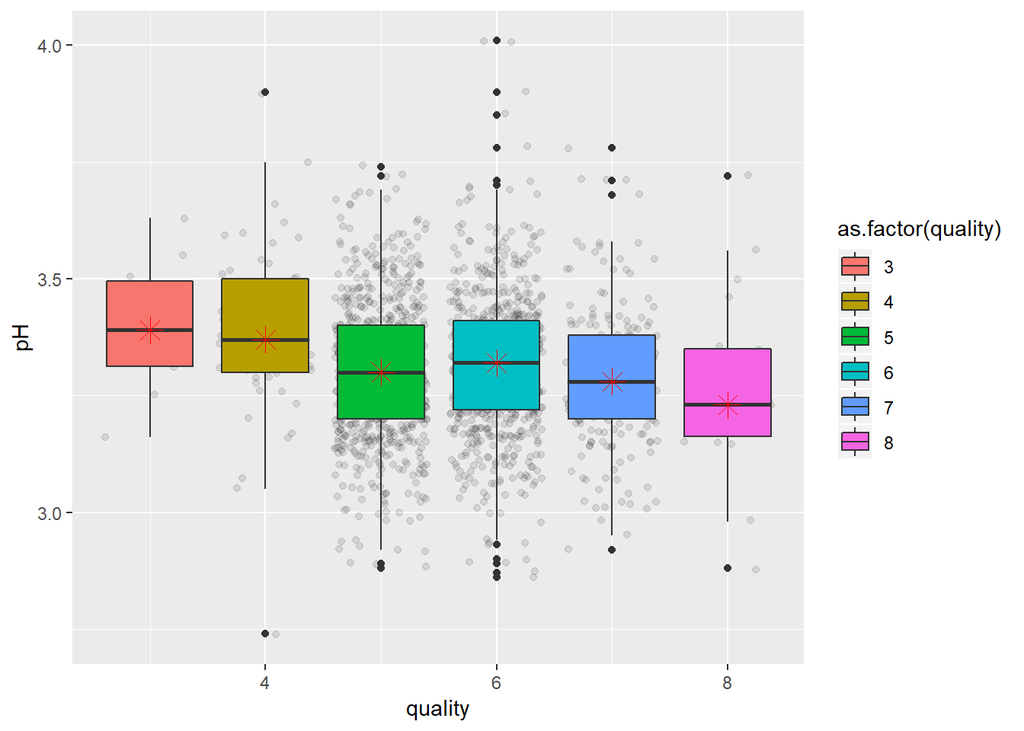

Lower pH means higher quality , i.e they are more acidic let’s see the relationship between pH and other acids

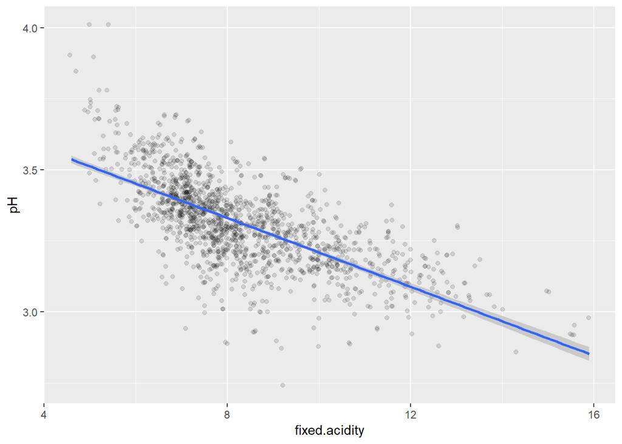

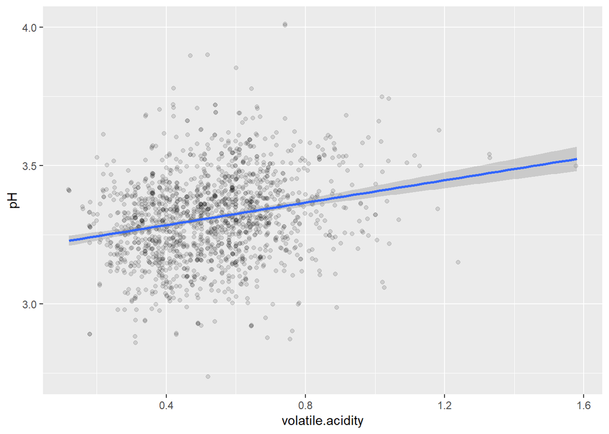

> these is weird it’s spoosed to be negative relation not positive !this could due to simpson’s paradox

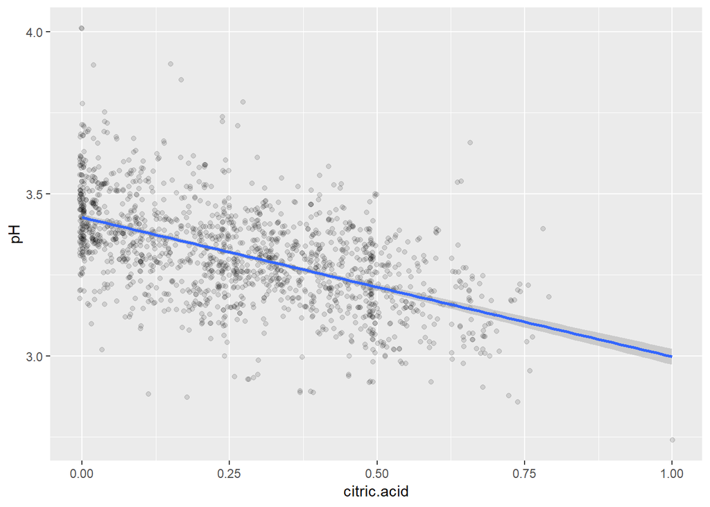

> Volatile acidity and citric acid have strong negative relationship

# Bivariate Analysis

> From above exploration Quality have higher relation with the following: 1- Alcohol 2- sulphates 3- volatile.acidity 4- citric acid

> From correlation plot ,the strongest relationship is between: 1- Quality and alcohol 2- Quality and volatile acidity 3- alcohol and desnsity 4- pH and citric acidity 5- pH and fixed acidity 6- citric acidity and volatile acidity 70 fixed acidity and citric acidity

# Multivariate Plots Section

> Now we know that quality is correlated the most with alcohol, let’s explore more if we make alcohol constant let’s see more quality with other variables

```
## [1] "bad"     "average" "good"
```

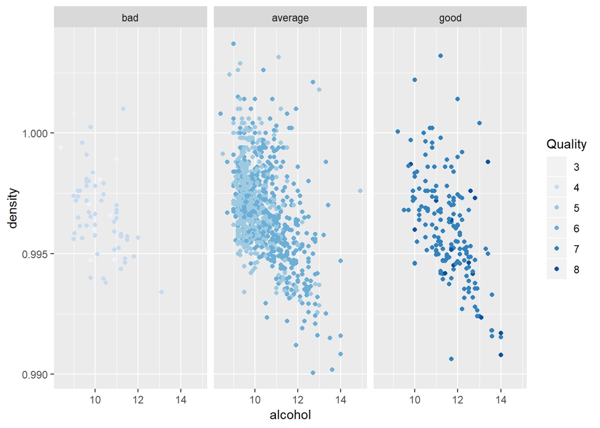

> From above graph we can see that at specific alcohol density doesn’t have effect in better quality

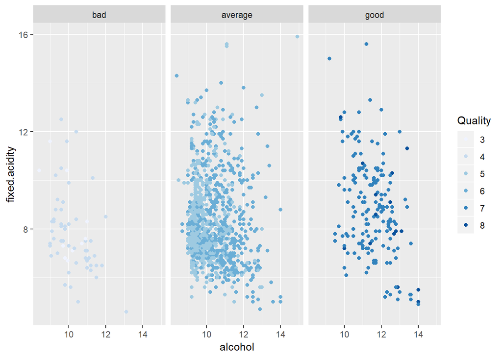

> > From above graph we can see that at specific alcohol fixed acidity doesn’t have effect in better quality

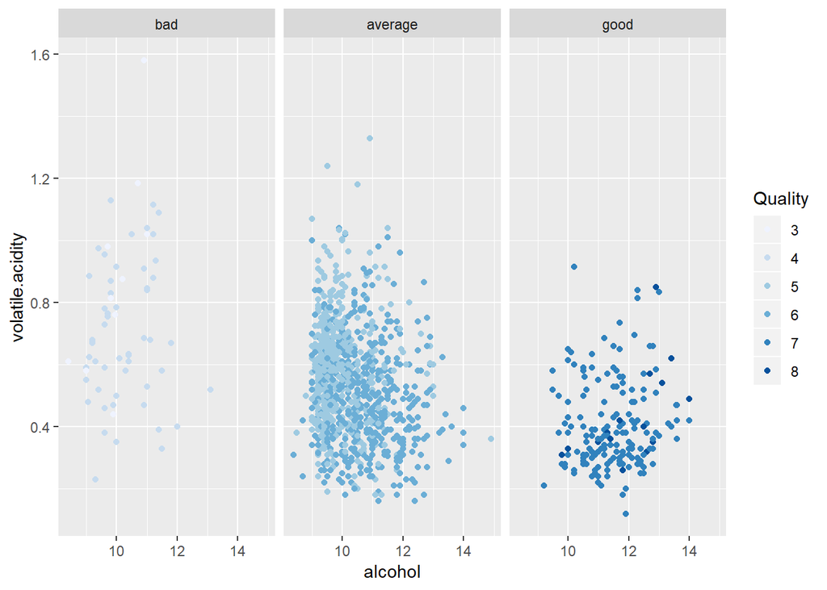

> Here it’s obvious that at specific alcohol better wine is correspond to lower volatile acidity

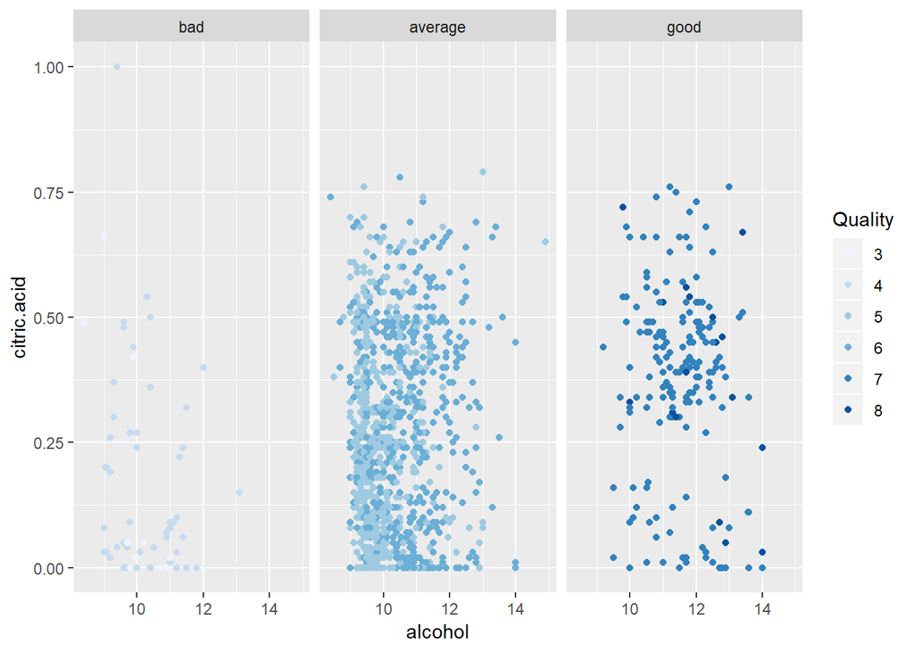

> Better wine correspond with higher citric acid